# Understanding and Predicting Event Participation: Demographic Factors and Categorical Outcomes Analysis

Nicolás Rubio García

November, 2023

## Introduction

In this project, a section of my undergraduate thesis is adapted, where I conduct a comprehensive analysis of the determinants that influence community participation in events proposed by the corporation. Both internal and external factors that could affect citizens’ willingness to engage in these activities have been evaluated.

Following this premise, three categories have been defined for this analysis: Single (participation in one event), Occasional (between 3 and 4 participations), and Frequent (more than 4 participations).

## The ordinal logit model

The chosen model for this task is the ordinal logit model. This corresponds to the case where there is a hierarchical ordering of categories, assuming a cumulative logistic distribution. The model starts with the latent variable ($y^∗$), which is unobserved and continuous, unlike the actual dependent variable that is categorical and ordered. The probabilities of occurrence for the highest category, $P_1,𝑃_2,𝑃_3 \in [0,1]$, are expressed as follows:

$$𝑃_1=𝐹(𝑐_1−𝑥_𝑖 𝛽)=1/(1+exp(−𝑐_1+𝑥_𝑖
𝛽))$$
$$𝑃_2=(𝑐_2−𝑥_𝑖
𝛽)=1/(1+exp(−𝑐_2+𝑥_𝑖 𝛽) )−𝑃_1$$
$$𝑃_3=1−𝑃_2−𝑃_1$$

Here, $𝑐_1$ and $𝑐_2$ are thresholds, $𝑥_𝑖$ is the observed covariate, and $𝛽$ represents the parameter vector. The probabilities are calculated using the logistic function.

## Exploring data

The initial step involves analyzing the data to identify the presence of missing values and assess the overall data completeness:

```
##               Año                ID   Participaciones            Genero
##              0.00              0.00              0.00              0.00
##              Edad             Grupo       Escolaridad              Zona
##              0.00              0.00              0.00              0.00
##      Departamento         Municipio Nombre del evento     clasificacion
##              0.43              4.95              0.00              0.00
```

As it could be seen, most variables are complete, and thus the model can be trained.

## Training the model

```
##
## Re-fitting to get Hessian
```

```
## Call:
## polr(formula = clasificacion ~ Genero + Zona + Escolaridad, data = df_part_2023,
##     method = "logistic")
##
## Coefficients:
##                               Value Std. Error  t value
## GeneroMujer                 0.17263    0.08411   2.0525
## Zonaurbana                 -1.10319    0.08715 -12.6588
## EscolaridadNinguno         -2.10437    1.06564  -1.9748
## EscolaridadNo especificado -1.34598    0.21599  -6.2316
## EscolaridadPosgrado        -0.19553    0.24528  -0.7972
## EscolaridadPrimaria        -0.37730    0.11427  -3.3017
## Escolaridadtécnico          0.11937    0.76379   0.1563
## EscolaridadTécnico         -0.30397    0.17101  -1.7775
## EscolaridadTecnólogo       -0.21382    0.21186  -1.0092
## EscolaridadUniversitario    0.04305    0.12327   0.3492
##
## Intercepts:
##                     Value    Std. Error t value
## Unico|Ocasional      -0.0369   0.0924    -0.3991
## Ocasional|Frecuente   1.4099   0.0992    14.2093
##
## Residual Deviance: 4474.803
## AIC: 4498.803
```

```
##
## ======================================================
##                                Dependent variable:
##                            ---------------------------
##                                   clasificacion
## ------------------------------------------------------
## GeneroMujer                          0.173**
##                                      (0.084)
##
## Zonaurbana                          -1.103***
##                                      (0.087)
##
## EscolaridadNinguno                  -2.104**
##                                      (1.066)
##
## EscolaridadNo especificado          -1.346***
##                                      (0.216)
##
## EscolaridadPosgrado                  -0.196
##                                      (0.245)
##
## EscolaridadPrimaria                 -0.377***
##                                      (0.114)
##
## Escolaridadtécnico                    0.119
##                                      (0.764)
##
## EscolaridadTécnico                   -0.304*
##                                      (0.171)
##
## EscolaridadTecnólogo                 -0.214
##                                      (0.212)
##
## EscolaridadUniversitario              0.043
##                                      (0.123)
##
## ------------------------------------------------------
## Observations                          2,770
## ======================================================
## Note:                      *p<0.1; **p<0.05; ***p<0.01
```

## Assumption tests

The specific assumption of this model is parallelism, where the parameters estimated for each category are assumed to be similar, and it is unnecessary to estimate them individually. Instead, they are treated as a single parameter. To test this assumption, the Brant test is typically used, with the null hypothesis $𝐻_0$ stating that the parallelism assumption is satisfied.

Additionally, the Hosmer-Lemeshow goodness-of-fit test is conducted, where the null hypothesis $H_0$ is: There are no significant discrepancies between the observed frequencies and those predicted by the model. Another goodness-of-fit test, the Lipsitz test, is conducted with the same null hypothesis ($H_0$) as the Hosmer-Lemeshow test. This test is applied by utilizing 5 risk quantiles.

```
## --------------------------------------------
## Test for X2  df  probability
## --------------------------------------------
## Omnibus      8.74    10  0.56
## Genero       0.8 1   0.37
## Zona     1.71    1   0.19
## Escolaridad  6.37    8   0.61
## --------------------------------------------
##
## H0: Parallel Regression Assumption holds
```

```
##
##  Hosmer and Lemeshow test (ordinal model)
##
## data:  df_part_2023$clasificacion, fitted(ologit_2023)
## X-squared = 13.065, df = 7, p-value = 0.07054
```

```
##
##  Lipsitz goodness of fit test for ordinal response models
##
## data:  formula:  clasificacion ~ Genero + Zona + Edad + Escolaridad
## LR statistic = 6.8217, df = 4, p-value = 0.1456
```

There is insufficient evidence to reject the null hypothesis $H_0$ in the tests. Therefore, it can be asserted that the parallelism assumption holds, and the model demonstrates a good prediction rate.

## Marginal effects

In order to interpret the probability results in linear terms, marginal effects are employed. These effects represent the impact of a change in the variable on the probability of falling into one of the alternatives. In other words, they are linearized parameters where the interpretation is not in comparison with a baseline alternative but rather on the probability of being in a specific category.

```
##
## Re-fitting to get Hessian
```

```
##                            effect.Unico effect.Ocasional effect.Frecuente
## GeneroMujer                      -0.037            0.022            0.015
## Zonaurbana                        0.246           -0.134           -0.112
## EscolaridadNinguno                0.266           -0.179           -0.086
## EscolaridadNo especificado        0.223           -0.145           -0.078
## EscolaridadPosgrado               0.041           -0.025           -0.016
## EscolaridadPrimaria               0.078           -0.047           -0.030
## Escolaridadtécnico               -0.026            0.015            0.011
## EscolaridadTécnico                0.063           -0.038           -0.024
## EscolaridadTecnólogo              0.045           -0.027           -0.018
## EscolaridadUniversitario         -0.009            0.006            0.004
```

```
##
##    Bachillerato         Ninguno No especificado        Posgrado        Primaria
##            1260               9             225              87             461
##         técnico         Técnico       Tecnólogo   Universitario
##               7             193             119             409
```

```
## [1] "Edad"        "Genero"      "Zona"        "Escolaridad" "Unico"
## [6] "Ocasional"   "Frecuente"
```

```
##
## Re-fitting to get Hessian
```

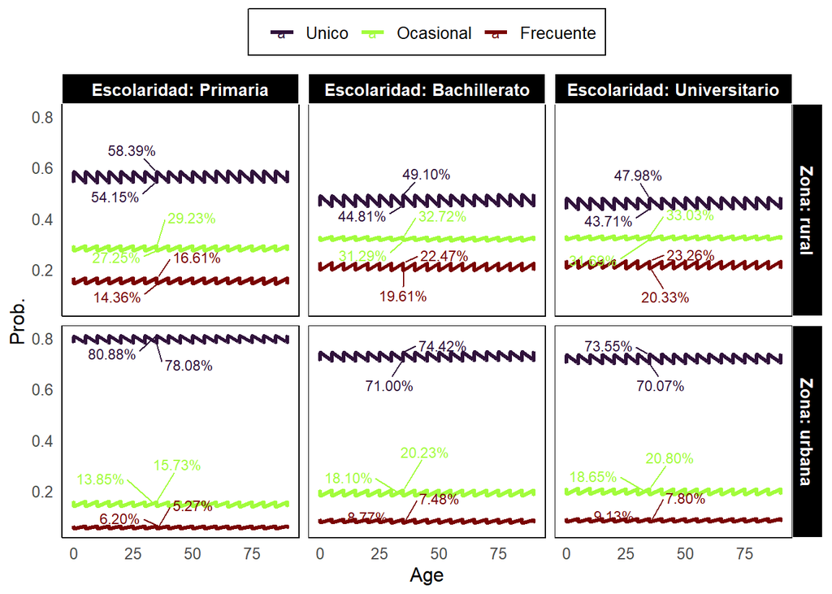